# Some analysis on the European Soccer Database

This database was compiled by Hugo Mathien and is available [here on Kaggle](https://www.kaggle.com/hugomathien/soccer).

As described by Hugo, the information gathered here is really impressive:

- +25,000 matches
- +10,000 players
- 11 European Countries with their lead championship
- Seasons 2008 to 2016
- Players and Teams' attributes* sourced from EA Sports' FIFA video game series, including the weekly updates
- Team line up with squad formation (X, Y coordinates)
- Betting odds from up to 10 providers
- Detailed match events (goal types, possession, corner, cross, fouls, cards etc…) for +10,000 matches

While this clearly represents quality material to perform in depth analysis and eventually predict matches outcome, I will focus here on performing exploratory analysis on teams, leagues or particular players and/or categories of players.

```python
#importing classic analysis libraries
import pandas as pd
import numpy as np

#sqlite3
import sqlite3

#plotting with plotly (offline default mode)
import plotly
plotly.__version__
import plotly.express as px
import plotly.graph_objects as go
#plotting directly in Jupyter notebook
import plotly.io as pio
pio.renderers.default='notebook'

#plotting with matplotlib and seaborn
import matplotlib.pyplot as plt
import seaborn as sns
```

Let's see what is in the database file

```python
conn = sqlite3.connect('database.sqlite')
tables = pd.read_sql("""SELECT * FROM sqlite_master WHERE type='table' ;""", conn)
tables
```

|  | type | name | tbl_name | rootpage | sql |
| --- | --- | --- | --- | --- | --- |
| 0 | table | sqlite_sequence | sqlite_sequence | 4 | CREATE TABLE sqlite_sequence(name,seq) |
| 1 | table | Player_Attributes | Player_Attributes | 11 | CREATE TABLE "Player_Attributes" (\n\t`id`\tIN... |
| 2 | table | Player | Player | 14 | CREATE TABLE `Player` (\n\t`id`\tINTEGER PRIMA... |
| 3 | table | Match | Match | 18 | CREATE TABLE `Match` (\n\t`id`\tINTEGER PRIMAR... |
| 4 | table | League | League | 24 | CREATE TABLE `League` (\n\t`id`\tINTEGER PRIMA... |
| 5 | table | Country | Country | 26 | CREATE TABLE `Country` (\n\t`id`\tINTEGER PRIM... |
| 6 | table | Team | Team | 29 | CREATE TABLE "Team" (\n\t`id`\tINTEGER PRIMARY... |
| 7 | table | Team_Attributes | Team_Attributes | 2 | CREATE TABLE `Team_Attributes` (\n\t`id`\tINTE... |

As we already knew, we've got quite a lot of information here, with the following tables:

- Match
- Player
- Player_Attributes
- League
- Country
- Team
- Team_attributes

We quickly draw the scheme above in order to be able to better visualize tables information and indexes/relations between tables. This will make our work much easier by being able to refer to it later on.

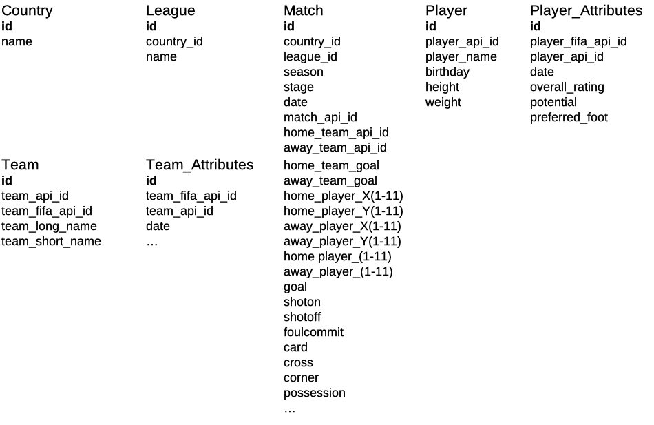

```python
from IPython.display import Image
Image(filename='Untitled 1.png', width=800, height=800)
```

Let's inspect country, league and team tables.

```python
pd.read_sql("""SELECT * FROM Country;""", conn)
```

|  | id | name |
| --- | --- | --- |
| 0 | 1 | Belgium |
| 1 | 1729 | England |
| 2 | 4769 | France |
| 3 | 7809 | Germany |
| 4 | 10257 | Italy |
| 5 | 13274 | Netherlands |
| 6 | 15722 | Poland |
| 7 | 17642 | Portugal |
| 8 | 19694 | Scotland |
| 9 | 21518 | Spain |
| 10 | 24558 | Switzerland |

```python
pd.read_sql("""SELECT * FROM League;""", conn)
```

|  | id | country_id | name |
| --- | --- | --- | --- |
| 0 | 1 | 1 | Belgium Jupiler League |
| 1 | 1729 | 1729 | England Premier League |
| 2 | 4769 | 4769 | France Ligue 1 |
| 3 | 7809 | 7809 | Germany 1. Bundesliga |
| 4 | 10257 | 10257 | Italy Serie A |
| 5 | 13274 | 13274 | Netherlands Eredivisie |
| 6 | 15722 | 15722 | Poland Ekstraklasa |
| 7 | 17642 | 17642 | Portugal Liga ZON Sagres |
| 8 | 19694 | 19694 | Scotland Premier League |
| 9 | 21518 | 21518 | Spain LIGA BBVA |
| 10 | 24558 | 24558 | Switzerland Super League |

We can see that there is only one league per country, and that league index and country index are equal.

```python
pd.read_sql("""SELECT * FROM Team LIMIT 20;""", conn)
```

|  | id | team_api_id | team_fifa_api_id | team_long_name | team_short_name |
| --- | --- | --- | --- | --- | --- |
| 0 | 1 | 9987 | 673.0 | KRC Genk | GEN |
| 1 | 2 | 9993 | 675.0 | Beerschot AC | BAC |
| 2 | 3 | 10000 | 15005.0 | SV Zulte-Waregem | ZUL |
| 3 | 4 | 9994 | 2007.0 | Sporting Lokeren | LOK |
| 4 | 5 | 9984 | 1750.0 | KSV Cercle Brugge | CEB |
| 5 | 6 | 8635 | 229.0 | RSC Anderlecht | AND |
| 6 | 7 | 9991 | 674.0 | KAA Gent | GEN |
| 7 | 8 | 9998 | 1747.0 | RAEC Mons | MON |
| 8 | 9 | 7947 | NaN | FCV Dender EH | DEN |
| 9 | 10 | 9985 | 232.0 | Standard de Liège | STL |
| 10 | 11 | 8203 | 110724.0 | KV Mechelen | MEC |
| 11 | 12 | 8342 | 231.0 | Club Brugge KV | CLB |
| 12 | 13 | 9999 | 546.0 | KSV Roeselare | ROS |
| 13 | 14 | 8571 | 100081.0 | KV Kortrijk | KOR |
| 14 | 15 | 4049 | NaN | Tubize | TUB |
| 15 | 16 | 9996 | 111560.0 | Royal Excel Mouscron | MOU |
| 16 | 17 | 10001 | 681.0 | KVC Westerlo | WES |
| 17 | 18 | 9986 | 670.0 | Sporting Charleroi | CHA |
| 18 | 614 | 9997 | 680.0 | Sint-Truidense VV | STT |
| 19 | 1034 | 9989 | 239.0 | Lierse SK | LIE |

Let's create a table of all the matches with home and away teams as well as scores.

```python
match_list = pd.read_sql("""
                            SELECT
                                m.id match_id,
                                c.name country,
                                l.name league,
                                m.season,
                                m.stage,
                                m.date,
                                ht.team_long_name home_team,
                                m.home_team_goal,
                                m.away_team_goal,
                                at.team_long_name away_team
                            FROM Match m
                            INNER JOIN Country c ON m.country_id = c.id
                            INNER JOIN League l ON m.league_id = l.id
                            INNER JOIN Team ht ON ht.team_api_id = m.home_team_api_id
                            INNER JOIN Team at ON at.team_api_id = m.away_team_api_id
                            ORDER BY 2, 4 DESC;""", conn)
match_list
```

|  | match_id | country | league | season | stage | date | home_team | home_team_goal | away_team_goal | away_team |
| --- | --- | --- | --- | --- | --- | --- | --- | --- | --- | --- |
| 0 | 1489 | Belgium | Belgium Jupiler League | 2015/2016 | 1 | 2015-07-24 00:00:00 | Sint-Truidense VV | 2 | 1 | Club Brugge KV |
| 1 | 1490 | Belgium | Belgium Jupiler League | 2015/2016 | 1 | 2015-07-25 00:00:00 | KV Kortrijk | 2 | 1 | Standard de Liège |
| 2 | 1491 | Belgium | Belgium Jupiler League | 2015/2016 | 1 | 2015-07-25 00:00:00 | KRC Genk | 3 | 1 | Oud-Heverlee Leuven |
| 3 | 1492 | Belgium | Belgium Jupiler League | 2015/2016 | 1 | 2015-07-25 00:00:00 | KV Oostende | 3 | 1 | KV Mechelen |
| 4 | 1493 | Belgium | Belgium Jupiler League | 2015/2016 | 1 | 2015-07-25 00:00:00 | SV Zulte-Waregem | 3 | 1 | Sporting Lokeren |
| ... | ... | ... | ... | ... | ... | ... | ... | ... | ... | ... |
| 25974 | 24733 | Switzerland | Switzerland Super League | 2008/2009 | 9 | 2008-09-13 00:00:00 | FC Basel | 2 | 0 | FC Luzern |
| 25975 | 24734 | Switzerland | Switzerland Super League | 2008/2009 | 9 | 2008-09-13 00:00:00 | Grasshopper Club Zürich | 0 | 0 | FC Aarau |
| 25976 | 24735 | Switzerland | Switzerland Super League | 2008/2009 | 9 | 2008-09-13 00:00:00 | Neuchâtel Xamax | 3 | 3 | FC Sion |
| 25977 | 24736 | Switzerland | Switzerland Super League | 2008/2009 | 9 | 2008-09-14 00:00:00 | AC Bellinzona | 1 | 2 | BSC Young Boys |
| 25978 | 24737 | Switzerland | Switzerland Super League | 2008/2009 | 9 | 2008-09-14 00:00:00 | FC Vaduz | 1 | 7 | FC Zürich |

25979 rows × 10 columns

```python
#example for Ligue 1 matches from the last recorded season
ligue1_1516 = pd.read_sql("""
                            SELECT
                                m.id match_id,
                                c.name country,
                                l.name league,
                                m.season,
                                m.stage,
                                m.date,
                                ht.team_long_name home_team,
                                m.home_team_goal,
                                m.away_team_goal,
                                at.team_long_name away_team
                            FROM Match m
                            INNER JOIN Country c ON m.country_id = c.id
                            INNER JOIN League l ON m.league_id = l.id
                            INNER JOIN Team ht ON ht.team_api_id = m.home_team_api_id
                            INNER JOIN Team at ON at.team_api_id = m.away_team_api_id
                            WHERE country='France' AND season='2015/2016'
                            ORDER BY 6 ASC;""", conn)
ligue1_1516
```

|  | match_id | country | league | season | stage | date | home_team | home_team_goal | away_team_goal | away_team |
| --- | --- | --- | --- | --- | --- | --- | --- | --- | --- | --- |
| 0 | 7431 | France | France Ligue 1 | 2015/2016 | 1 | 2015-08-07 00:00:00 | LOSC Lille | 0 | 1 | Paris Saint-Germain |
| 1 | 7429 | France | France Ligue 1 | 2015/2016 | 1 | 2015-08-08 00:00:00 | SC Bastia | 2 | 1 | Stade Rennais FC |
| 2 | 7433 | France | France Ligue 1 | 2015/2016 | 1 | 2015-08-08 00:00:00 | Olympique de Marseille | 0 | 1 | SM Caen |
| 3 | 7434 | France | France Ligue 1 | 2015/2016 | 1 | 2015-08-08 00:00:00 | Montpellier Hérault SC | 0 | 2 | Angers SCO |
| 4 | 7435 | France | France Ligue 1 | 2015/2016 | 1 | 2015-08-08 00:00:00 | FC Nantes | 1 | 0 | En Avant de Guingamp |
| ... | ... | ... | ... | ... | ... | ... | ... | ... | ... | ... |
| 375 | 7744 | France | France Ligue 1 | 2015/2016 | 38 | 2016-05-14 00:00:00 | FC Lorient | 1 | 0 | GFC Ajaccio |
| 376 | 7745 | France | France Ligue 1 | 2015/2016 | 38 | 2016-05-14 00:00:00 | Paris Saint-Germain | 4 | 0 | FC Nantes |
| 377 | 7746 | France | France Ligue 1 | 2015/2016 | 38 | 2016-05-14 00:00:00 | SM Caen | 1 | 0 | Girondins de Bordeaux |
| 378 | 7747 | France | France Ligue 1 | 2015/2016 | 38 | 2016-05-14 00:00:00 | Stade de Reims | 4 | 1 | Olympique Lyonnais |
| 379 | 7748 | France | France Ligue 1 | 2015/2016 | 38 | 2016-05-14 00:00:00 | Stade Rennais FC | 1 | 2 | SC Bastia |

380 rows × 10 columns

# Analysis on leagues

Say our initial aim is to focus on European national leagues, and we expect to get some statistics (on player characteristics, in terms of total goals, fouls, ...) in order to compare them.

### What are the leagues where there are the most goals?

Of course this is not a clear indicator of the quality of the league, since various factors influence the total number of goals in a league (presence of top scorers, average quality of strikers, average quality of defenses, type of play, ...).  
Let's try to draw a graph with all leagues total goals scored for each year.

```python
total_goals = pd.read_sql("""
                            SELECT
                                m.season,
                                c.name country,
                                l.name league,
                                SUM(m.home_team_goal + m.away_team_goal) total_goals
                            FROM Match m
                            INNER JOIN Country c ON c.id = m.country_id
                            INNER JOIN League l ON l.id = m.league_id
                            GROUP BY 1, 2
                            ORDER BY 1 DESC, 4 DESC;""", conn)
total_goals
```

|  | season | country | league | total_goals |
| --- | --- | --- | --- | --- |
| 0 | 2015/2016 | Spain | Spain LIGA BBVA | 1043 |
| 1 | 2015/2016 | England | England Premier League | 1026 |
| 2 | 2015/2016 | Italy | Italy Serie A | 979 |
| 3 | 2015/2016 | France | France Ligue 1 | 960 |
| 4 | 2015/2016 | Netherlands | Netherlands Eredivisie | 912 |
| ... | ... | ... | ... | ... |
| 83 | 2008/2009 | Belgium | Belgium Jupiler League | 855 |
| 84 | 2008/2009 | Portugal | Portugal Liga ZON Sagres | 552 |
| 85 | 2008/2009 | Scotland | Scotland Premier League | 548 |
| 86 | 2008/2009 | Switzerland | Switzerland Super League | 540 |
| 87 | 2008/2009 | Poland | Poland Ekstraklasa | 524 |

88 rows × 4 columns

```python
#plotting total goals scored per year
fig = px.line(total_goals, x='season', y='total_goals', color='league')
fig.show()
```

[interactive chart not shown]

We can see that there is a lot of disparity between leagues, and it looks like we are lacking data for the 2013/2014 Belgian championship.  
Let's focus on the top 6 leagues.

```python
#plotting total goals scored per year for the top 6 leagues in terms of total goal scored

#creating a list of the seasons to order the chart's x_axis
seasons_list = ['2008/2009', '2009/2010', '2010/2011', '2011/2012', '2012/2013', '2013/2014', '2014/2015', '2015/2016', '2016/2017', '2017/2018', '2018/2019']
total_goals_top = total_goals[total_goals['country'].isin(['Spain', 'England', 'Italy', 'France', 'Netherlands', 'Germany'])]
```

[output not shown]

Between the 2008/2009 season and 2015/2016 season, the gap between #1 and #5 leagues in terms of total goals scored has slightly decreased.  
In particular, total goals scored in the French Ligue 1 have considerably increased (+100 approx.), while it decreased for German Bundesliga, which is no longer in the top 5.  
At the same time, there is also a noticeable decrease in the Spanish Liga BBVA, from 1101 to 1043.  
There was also a huge increase for the Dutch championship total between the 2009/2010 season and the 2011/2012 season, which was quickly mitigated with total goals scored coming back to approx 900 for the last season.

### Focus on top teams from each league

Seeing the total goals scored for each league is interesting, but we would now rather see which are the top 3 contributing teams for each league.

```python
#creating a table with a single column for teams and a single column for goals scored per match: example with France
# test = pd.read_sql("""
#                     SELECT
#                         m.season,
#                         l.name league,
#                         c.name country,
#                         m.stage,
#                         t.team_api_id,
#                         t.team_long_name team,
#                         CASE
#                             WHEN t.team_api_id=m.home_team_api_id THEN m.home_team_goal
#                             WHEN t.team_api_id=m.away_team_api_id THEN m.away_team_goal
#                             END goals
#                     FROM Match m
#                     INNER JOIN League l ON m.league_id = l.id
#                     INNER JOIN Country c ON c.id = m.country_id
#                     INNER JOIN Team t ON t.team_api_id = m.home_team_api_id OR t.team_api_id = m.away_team_api_id
#                     WHERE m.season='2015/2016' AND c.name='France' AND m.stage=1;""", conn)
# test
```

```python
#now doing the same for all countries and seasons and selecting the top 3 teams from each league
# top_teams = pd.read_sql("""
#                     WITH team_goals AS
#                         (SELECT
#                             m.season,
#                             l.name league,
#                             c.name country,
#                             m.stage,
#                             t.team_api_id,
#                             t.team_long_name team,
#                             CASE
#                                 WHEN t.team_api_id=m.home_team_api_id THEN m.home_team_goal
#                                 WHEN t.team_api_id=m.away_team_api_id THEN m.away_team_goal
#                                 END goals
#                         FROM Match m
#                         INNER JOIN League l ON m.league_id = l.id
#                         INNER JOIN Country c ON c.id = m.country_id
#                         INNER JOIN Team t ON t.team_api_id = m.home_team_api_id OR t.team_api_id = m.away_team_api_id),

#                     classified_teams AS
#                         (SELECT
#                             tg.season,
#                             tg.league,
#                             tg.team,
#                             ROW_NUMBER() OVER (PARTITION BY tg.season, tg.league ORDER BY SUM(tg.goals) DESC) AS rank,
#                             SUM(tg.goals) total_team_goals,
#                             CAST(SUM(tg.goals) AS float)/CAST((SELECT SUM(tg2.goals) FROM team_goals tg2
#                                                                 WHERE tg2.season=tg.season AND tg2.league=tg.league
#                                                                 GROUP BY tg2.season, tg2.league) AS float) pct_total_league_goals,
#                             (SELECT SUM(tg2.goals) FROM team_goals tg2
#                             WHERE tg2.season=tg.season AND tg2.league=tg.league
#                             GROUP BY tg2.season, tg2.league) total_league_goals
#                         FROM team_goals tg
#                         GROUP BY 1, 3
#                         ORDER BY 1, 2, 4 ASC)

#                     SELECT *
#                     FROM classified_teams
#                     WHERE rank <=3;""", conn)
# top_teams
```

Let's see the output for the 2015/2016 season and compare the top clubs from each league.

```python
# top_teams_1516 = top_teams[top_teams['season']=='2015/2016']
# top_teams_1516
```

```python
# #creating three subsets of the top_teams_1516 dataframe in order to plot a grouped bar chart
# rank1 = top_teams_1516[top_teams_1516['rank']==1]
# rank2 = top_teams_1516[top_teams_1516['rank']==2]
# rank3 = top_teams_1516[top_teams_1516['rank']==3]

# fig = go.Figure(data=[
#     go.Bar(x=rank1['league'], y=rank1['total_team_goals'], text=rank1['team'], textposition='auto'),
#     go.Bar(x=rank2['league'], y=rank2['total_team_goals'], text=rank2['team'], textposition='auto'),
#     go.Bar(x=rank3['league'], y=rank3['total_team_goals'], text=rank3['team'], textposition='auto')
# ])
# # Change the bar mode
# fig.update_layout(barmode='group',
#                   showlegend=False,
#                   title='Top 3 teams (by total goals scored) per league in the 2015/2016 season',
#                  yaxis_title='total goals scored')
# fig.show()
```

# Analyzing data with pandas

We will now use Python Pandas library in order to store dataframes of particular interest and pursue further analysis.

## Objectives

- Determining hegemony patterns in particular leagues: whether one or several team remained at the top in terms of points (3 points for a win, 1 for a draw, 0 for a defeat)
- Analyzing teams attributes, and see whether there is a correlation between team attributes and points
- Analyzing players attributes

We only speak about correlation (and not causation) at this point, since the relation between players quality and team scores, for example, is ambiguous: better players will quite logically enhance the overall team attributes and level, leading to more points, and at the same time, famous and better ranked teams tend to attract top level players.

## Compiling data in pandas dataframes

We chose to focus on 6 of the major European leagues:

- Spain LIGA BBVA,
- England Premier League,
- Italy Serie A,
- France Ligue 1,
- Netherlands Eredivisie,
- Germany 1.Bundesliga

```python
#Creating a dataframe with match information: it will be the base for total points per team per season analysis
#The league ids we consider is the following: '1729', '4769', '7809', '10257', '13274', '21518'
df_match = pd.read_sql("""
                        SELECT
                            m.id,
                            m.country_id,
                            c.name country,
                            m.league_id,
                            l.name league,
                            m.season,
                            m.stage,
                            m.match_api_id,
                            m.home_team_api_id,
                            m.away_team_api_id,
                            m.home_team_goal,
                            m.away_team_goal
                        FROM Match m
                        INNER JOIN Country c ON c.id = m.country_id
                        INNER JOIN League l ON l.id = m.league_id
                        WHERE l.id IN ('1729', '4769', '7809', '10257', '13274', '21518');""", conn)
df_match.head()
```

|  | id | country_id | country | league_id | league | season | stage | match_api_id | home_team_api_id | away_team_api_id | home_team_goal | away_team_goal |
| --- | --- | --- | --- | --- | --- | --- | --- | --- | --- | --- | --- | --- |
| 0 | 1729 | 1729 | England | 1729 | England Premier League | 2008/2009 | 1 | 489042 | 10260 | 10261 | 1 | 1 |
| 1 | 1730 | 1729 | England | 1729 | England Premier League | 2008/2009 | 1 | 489043 | 9825 | 8659 | 1 | 0 |
| 2 | 1731 | 1729 | England | 1729 | England Premier League | 2008/2009 | 1 | 489044 | 8472 | 8650 | 0 | 1 |
| 3 | 1732 | 1729 | England | 1729 | England Premier League | 2008/2009 | 1 | 489045 | 8654 | 8528 | 2 | 1 |
| 4 | 1733 | 1729 | England | 1729 | England Premier League | 2008/2009 | 1 | 489046 | 10252 | 8456 | 4 | 2 |

```python
#Creating the team, country and league dataframes
df_team = pd.read_sql("""SELECT * FROM Team;""", conn)

df_country = pd.read_sql("""SELECT * FROM Country
                        WHERE id IN ('1729', '4769', '7809', '10257', '13274', '21518');""", conn)

df_league = pd.read_sql("""SELECT * FROM League
                        WHERE id IN ('1729', '4769', '7809', '10257', '13274', '21518');""", conn)
```

```python
df_team
```

|  | id | team_api_id | team_fifa_api_id | team_long_name | team_short_name |
| --- | --- | --- | --- | --- | --- |
| 0 | 1 | 9987 | 673.0 | KRC Genk | GEN |
| 1 | 2 | 9993 | 675.0 | Beerschot AC | BAC |
| 2 | 3 | 10000 | 15005.0 | SV Zulte-Waregem | ZUL |
| 3 | 4 | 9994 | 2007.0 | Sporting Lokeren | LOK |
| 4 | 5 | 9984 | 1750.0 | KSV Cercle Brugge | CEB |
| ... | ... | ... | ... | ... | ... |
| 294 | 49479 | 10190 | 898.0 | FC St. Gallen | GAL |
| 295 | 49837 | 10191 | 1715.0 | FC Thun | THU |
| 296 | 50201 | 9777 | 324.0 | Servette FC | SER |
| 297 | 50204 | 7730 | 1862.0 | FC Lausanne-Sports | LAU |
| 298 | 51606 | 7896 | NaN | Lugano | LUG |

299 rows × 5 columns

```python
#let's select the teams from the leagues that interest us
df_team = df_team.merge(df_match, how='left',
                        left_on='team_api_id',
                        right_on='home_team_api_id')

#Selecting only relevant columns and dropping duplicates, resetting index and renaming columns
df_team = df_team[['id_x', 'team_api_id', 'team_fifa_api_id', 'team_long_name', 'team_short_name', 'league_id']].drop_duplicates()
df_team.dropna(subset=['league_id'], inplace=True)
df_team.reset_index(drop=True)
df_team.rename(columns={'id_x':'id'}, inplace=True)
```

We need to build a dataframe containing the players list from each team, for each league (among the 6 major leagues we chose to study) and each season.

```python
df_match_player = pd.read_sql("""
                                SELECT
                                    id, season, league_id, home_team_api_id, away_team_api_id,
                                    home_player_1, home_player_2, home_player_3, home_player_4, home_player_5,
                                    home_player_6, home_player_7, home_player_8, home_player_9, home_player_10, home_player_11,
                                    away_player_1, away_player_2, away_player_3, away_player_4, away_player_5,
                                    away_player_6, away_player_7, away_player_8, away_player_9, away_player_10, away_player_11
                                FROM Match
                                WHERE league_id IN ('1729', '4769', '7809', '10257', '13274', '21518');""", conn)
```

```python
#Creating the team attributes dataframe
df_teamatt = pd.read_sql("""SELECT * FROM Team_Attributes;""", conn)
df_teamatt.head()
```

|  | id | team_fifa_api_id | team_api_id | date | buildUpPlaySpeed | buildUpPlaySpeedClass | buildUpPlayDribbling | buildUpPlayDribblingClass | buildUpPlayPassing | buildUpPlayPassingClass | ... | chanceCreationShooting | chanceCreationShootingClass | chanceCreationPositioningClass | defencePressure | defencePressureClass | defenceAggression | defenceAggressionClass | defenceTeamWidth | defenceTeamWidthClass | defenceDefenderLineClass |
| --- | --- | --- | --- | --- | --- | --- | --- | --- | --- | --- | --- | --- | --- | --- | --- | --- | --- | --- | --- | --- | --- |
| 0 | 1 | 434 | 9930 | 2010-02-22 00:00:00 | 60 | Balanced | NaN | Little | 50 | Mixed | ... | 55 | Normal | Organised | 50 | Medium | 55 | Press | 45 | Normal | Cover |
| 1 | 2 | 434 | 9930 | 2014-09-19 00:00:00 | 52 | Balanced | 48.0 | Normal | 56 | Mixed | ... | 64 | Normal | Organised | 47 | Medium | 44 | Press | 54 | Normal | Cover |
| 2 | 3 | 434 | 9930 | 2015-09-10 00:00:00 | 47 | Balanced | 41.0 | Normal | 54 | Mixed | ... | 64 | Normal | Organised | 47 | Medium | 44 | Press | 54 | Normal | Cover |
| 3 | 4 | 77 | 8485 | 2010-02-22 00:00:00 | 70 | Fast | NaN | Little | 70 | Long | ... | 70 | Lots | Organised | 60 | Medium | 70 | Double | 70 | Wide | Cover |
| 4 | 5 | 77 | 8485 | 2011-02-22 00:00:00 | 47 | Balanced | NaN | Little | 52 | Mixed | ... | 52 | Normal | Organised | 47 | Medium | 47 | Press | 52 | Normal | Cover |

5 rows × 25 columns

We then need to split between home and away teams and players (we begin with home teams and players), and remodel the dataframe in order to get only season, team and players as columns.

```python
#Splitting between home and away teams and players
df_home_player = df_match_player[['season', 'home_team_api_id', 'home_player_1', 'home_player_2', 'home_player_3',
                                    'home_player_4', 'home_player_5', 'home_player_6', 'home_player_7', 'home_player_8',
                                    'home_player_9', 'home_player_10', 'home_player_11']]
df_home_player = pd.melt(df_home_player, id_vars=['season', 'home_team_api_id'],
                         value_vars=['home_player_1', 'home_player_2', 'home_player_3',
                                    'home_player_4', 'home_player_5', 'home_player_6',
                                    'home_player_7', 'home_player_8', 'home_player_9',
                                    'home_player_10', 'home_player_11'],
                         var_name='player_pos', value_name='player')
df_home_player.head()
```

|  | season | home_team_api_id | player_pos | player |
| --- | --- | --- | --- | --- |
| 0 | 2008/2009 | 10260 | home_player_1 | 30726.0 |
| 1 | 2008/2009 | 9825 | home_player_1 | 23686.0 |
| 2 | 2008/2009 | 8472 | home_player_1 | 32562.0 |
| 3 | 2008/2009 | 8654 | home_player_1 | 36374.0 |
| 4 | 2008/2009 | 10252 | home_player_1 | 30380.0 |

```python
df_home_player.info()
```

```
<class 'pandas.core.frame.DataFrame'>
RangeIndex: 187363 entries, 0 to 187362
Data columns (total 4 columns):
 #   Column            Non-Null Count   Dtype
---  ------            --------------   -----
 0   season            187363 non-null  object
 1   home_team_api_id  187363 non-null  int64
 2   player_pos        187363 non-null  object
 3   player            184463 non-null  float64
dtypes: float64(1), int64(1), object(2)
memory usage: 5.7+ MB
```

Then, we drop null values and also drop duplicate entries - correponding to a player multiple appearances with his team throughout each year - and eventually rename columns and drop the player_pos column which won't be useful for our purpose.  
We also rename the 'home_team_api_id' column as 'team_api_id', as we will perform the same manipulation to the dataframe containing away teams and players before concatenating them.

```python
#Removing the 'player_pos' column
df_home_player.drop(columns=['player_pos'], inplace=True)

#Dropping duplicates and null values
df_home_player.drop_duplicates(subset=['season', 'home_team_api_id', 'player'], inplace=True)
df_home_player.dropna(inplace=True)

#Renaming columns
df_home_player.rename(columns={'home_team_api_id':'team_api_id'}, inplace=True)
df_home_player.info()
```

```
<class 'pandas.core.frame.DataFrame'>
Int64Index: 21320 entries, 0 to 187271
Data columns (total 3 columns):
 #   Column       Non-Null Count  Dtype
---  ------       --------------  -----
 0   season       21320 non-null  object
 1   team_api_id  21320 non-null  int64
 2   player       21320 non-null  float64
dtypes: float64(1), int64(1), object(1)
memory usage: 666.2+ KB
```

We can then do the same for away teams and players.

```python
df_away_player = df_match_player[['season', 'away_team_api_id', 'away_player_1', 'away_player_2', 'away_player_3',
                                    'away_player_4', 'away_player_5', 'away_player_6',
                                    'away_player_7', 'away_player_8', 'away_player_9',
                                    'away_player_10', 'away_player_11']]
df_away_player = pd.melt(df_away_player, id_vars=['season', 'away_team_api_id'],
                         value_vars=['away_player_1', 'away_player_2', 'away_player_3',
                                    'away_player_4', 'away_player_5', 'away_player_6',
                                    'away_player_7', 'away_player_8', 'away_player_9',
                                    'away_player_10', 'away_player_11'],
                         var_name='player_pos', value_name='player')

df_away_player.drop(columns=['player_pos'], inplace=True)
df_away_player.drop_duplicates(subset=['season', 'away_team_api_id', 'player'], inplace=True)
df_away_player.dropna(inplace=True)
df_away_player.rename(columns={'away_team_api_id':'team_api_id'}, inplace=True)
df_away_player.info()
```

```
<class 'pandas.core.frame.DataFrame'>
Int64Index: 21615 entries, 0 to 187308
Data columns (total 3 columns):
 #   Column       Non-Null Count  Dtype
---  ------       --------------  -----
 0   season       21615 non-null  object
 1   team_api_id  21615 non-null  int64
 2   player       21615 non-null  float64
dtypes: float64(1), int64(1), object(1)
memory usage: 675.5+ KB
```

We have now compiled all home teams' players as well as away teams' players. We can concat the two dataframes and drop duplicates.

```python
df_team_player = pd.concat([df_home_player, df_away_player], ignore_index=True).drop_duplicates(subset=['season', 'team_api_id', 'player'])
df_team_player.head()
```

|  | season | team_api_id | player |
| --- | --- | --- | --- |
| 0 | 2008/2009 | 10260 | 30726.0 |
| 1 | 2008/2009 | 9825 | 23686.0 |
| 2 | 2008/2009 | 8472 | 32562.0 |
| 3 | 2008/2009 | 8654 | 36374.0 |
| 4 | 2008/2009 | 10252 | 30380.0 |

We just need to retrieve information on players from the database.

```python
df_player = pd.read_sql("""SELECT * FROM Player;""", conn)
df_playeratt = pd.read_sql("""SELECT * FROM Player_Attributes;""", conn)
```

## Cleaning the dataframes

```python
df_match.info()
```

```
<class 'pandas.core.frame.DataFrame'>
RangeIndex: 17033 entries, 0 to 17032
Data columns (total 12 columns):
 #   Column            Non-Null Count  Dtype
---  ------            --------------  -----
 0   id                17033 non-null  int64
 1   country_id        17033 non-null  int64
 2   country           17033 non-null  object
 3   league_id         17033 non-null  int64
 4   league            17033 non-null  object
 5   season            17033 non-null  object
 6   stage             17033 non-null  int64
 7   match_api_id      17033 non-null  int64
 8   home_team_api_id  17033 non-null  int64
 9   away_team_api_id  17033 non-null  int64
 10  home_team_goal    17033 non-null  int64
 11  away_team_goal    17033 non-null  int64
dtypes: int64(9), object(3)
memory usage: 1.6+ MB
```

There are no null values.

```python
df_match.duplicated().value_counts()
```

```
False    17033
dtype: int64
```

No duplicates either.

```python
print(df_team.info())
print(df_team.duplicated().value_counts())
```

```
<class 'pandas.core.frame.DataFrame'>
Int64Index: 189 entries, 25 to 17109
Data columns (total 6 columns):
 #   Column            Non-Null Count  Dtype
---  ------            --------------  -----
 0   id                189 non-null    int64
 1   team_api_id       189 non-null    int64
 2   team_fifa_api_id  188 non-null    float64
 3   team_long_name    189 non-null    object
 4   team_short_name   189 non-null    object
 5   league_id         189 non-null    float64
dtypes: float64(2), int64(2), object(2)
memory usage: 10.3+ KB
None
False    189
dtype: int64
```

No null values except for one in the 'team_fifa_api_id' which we won't be using here since the team attributes dataframe has all entries for the 'team_api_id'. No duplicates either.

```python
df_teamatt.head(10)
```

|  | id | team_fifa_api_id | team_api_id | date | buildUpPlaySpeed | buildUpPlaySpeedClass | buildUpPlayDribbling | buildUpPlayDribblingClass | buildUpPlayPassing | buildUpPlayPassingClass | ... | chanceCreationShooting | chanceCreationShootingClass | chanceCreationPositioningClass | defencePressure | defencePressureClass | defenceAggression | defenceAggressionClass | defenceTeamWidth | defenceTeamWidthClass | defenceDefenderLineClass |
| --- | --- | --- | --- | --- | --- | --- | --- | --- | --- | --- | --- | --- | --- | --- | --- | --- | --- | --- | --- | --- | --- |
| 0 | 1 | 434 | 9930 | 2010-02-22 00:00:00 | 60 | Balanced | NaN | Little | 50 | Mixed | ... | 55 | Normal | Organised | 50 | Medium | 55 | Press | 45 | Normal | Cover |
| 1 | 2 | 434 | 9930 | 2014-09-19 00:00:00 | 52 | Balanced | 48.0 | Normal | 56 | Mixed | ... | 64 | Normal | Organised | 47 | Medium | 44 | Press | 54 | Normal | Cover |
| 2 | 3 | 434 | 9930 | 2015-09-10 00:00:00 | 47 | Balanced | 41.0 | Normal | 54 | Mixed | ... | 64 | Normal | Organised | 47 | Medium | 44 | Press | 54 | Normal | Cover |
| 3 | 4 | 77 | 8485 | 2010-02-22 00:00:00 | 70 | Fast | NaN | Little | 70 | Long | ... | 70 | Lots | Organised | 60 | Medium | 70 | Double | 70 | Wide | Cover |
| 4 | 5 | 77 | 8485 | 2011-02-22 00:00:00 | 47 | Balanced | NaN | Little | 52 | Mixed | ... | 52 | Normal | Organised | 47 | Medium | 47 | Press | 52 | Normal | Cover |
| 5 | 6 | 77 | 8485 | 2012-02-22 00:00:00 | 58 | Balanced | NaN | Little | 62 | Mixed | ... | 55 | Normal | Organised | 40 | Medium | 40 | Press | 60 | Normal | Cover |
| 6 | 7 | 77 | 8485 | 2013-09-20 00:00:00 | 62 | Balanced | NaN | Little | 45 | Mixed | ... | 55 | Normal | Organised | 42 | Medium | 42 | Press | 60 | Normal | Cover |
| 7 | 8 | 77 | 8485 | 2014-09-19 00:00:00 | 58 | Balanced | 64.0 | Normal | 62 | Mixed | ... | 57 | Normal | Organised | 41 | Medium | 42 | Press | 60 | Normal | Cover |
| 8 | 9 | 77 | 8485 | 2015-09-10 00:00:00 | 59 | Balanced | 64.0 | Normal | 53 | Mixed | ... | 63 | Normal | Free Form | 49 | Medium | 45 | Press | 63 | Normal | Cover |
| 9 | 10 | 614 | 8576 | 2010-02-22 00:00:00 | 60 | Balanced | NaN | Little | 40 | Mixed | ... | 55 | Normal | Organised | 30 | Deep | 70 | Double | 30 | Narrow | Offside Trap |

10 rows × 25 columns

We can see that columns display information by 'pair': one column indicates the value according to one attribute, while the other contains a categorical variable (slow, fast balanced for example).  
Let's look at the 'buildUpPlaySpeed' and 'buildUpPlaySpeedClass' columns for example.

```python
df_teamatt.groupby('buildUpPlaySpeedClass')['buildUpPlaySpeed'].describe()
```

| buildUpPlaySpeedClass | count | mean | std | min | 25% | 50% | 75% | max |
| --- | --- | --- | --- | --- | --- | --- | --- | --- |
| Balanced | 1184.0 | 51.925676 | 8.567738 | 34.0 | 46.0 | 52.0 | 59.0 | 66.0 |
| Fast | 172.0 | 69.767442 | 2.578246 | 67.0 | 68.0 | 70.0 | 70.0 | 80.0 |
| Slow | 102.0 | 29.509804 | 2.570761 | 20.0 | 30.0 | 30.0 | 30.0 | 33.0 |

```python
df_teamatt.info()
```

```
<class 'pandas.core.frame.DataFrame'>
RangeIndex: 1458 entries, 0 to 1457
Data columns (total 25 columns):
 #   Column                          Non-Null Count  Dtype
---  ------                          --------------  -----
 0   id                              1458 non-null   int64
 1   team_fifa_api_id                1458 non-null   int64
 2   team_api_id                     1458 non-null   int64
 3   date                            1458 non-null   object
 4   buildUpPlaySpeed                1458 non-null   int64
 5   buildUpPlaySpeedClass           1458 non-null   object
 6   buildUpPlayDribbling            489 non-null    float64
 7   buildUpPlayDribblingClass       1458 non-null   object
 8   buildUpPlayPassing              1458 non-null   int64
 9   buildUpPlayPassingClass         1458 non-null   object
```

[output cut: 17 more lines]

It seems like the dataframe is complete except for the 'buildUpPlayDribbling' column, which lacks at least 2/3 of data. Quite srangely, there aren't any missing data in the corresponding 'buildUpPlayDribblingClass' column.  
Let's investigate on where these data are lacking the most.

```python
df_teamatt['date'].unique()
```

```
array(['2010-02-22 00:00:00', '2014-09-19 00:00:00',
       '2015-09-10 00:00:00', '2011-02-22 00:00:00',
       '2012-02-22 00:00:00', '2013-09-20 00:00:00'], dtype=object)
```

```python
df_teamatt.groupby('date').count()
```

| date | id | team_fifa_api_id | team_api_id | buildUpPlaySpeed | buildUpPlaySpeedClass | buildUpPlayDribbling | buildUpPlayDribblingClass | buildUpPlayPassing | buildUpPlayPassingClass | buildUpPlayPositioningClass | ... | chanceCreationShooting | chanceCreationShootingClass | chanceCreationPositioningClass | defencePressure | defencePressureClass | defenceAggression | defenceAggressionClass | defenceTeamWidth | defenceTeamWidthClass | defenceDefenderLineClass |
| --- | --- | --- | --- | --- | --- | --- | --- | --- | --- | --- | --- | --- | --- | --- | --- | --- | --- | --- | --- | --- | --- |
| 2010-02-22 00:00:00 | 241 | 241 | 241 | 241 | 241 | 0 | 241 | 241 | 241 | 241 | ... | 241 | 241 | 241 | 241 | 241 | 241 | 241 | 241 | 241 | 241 |
| 2011-02-22 00:00:00 | 244 | 244 | 244 | 244 | 244 | 0 | 244 | 244 | 244 | 244 | ... | 244 | 244 | 244 | 244 | 244 | 244 | 244 | 244 | 244 | 244 |
| 2012-02-22 00:00:00 | 242 | 242 | 242 | 242 | 242 | 0 | 242 | 242 | 242 | 242 | ... | 242 | 242 | 242 | 242 | 242 | 242 | 242 | 242 | 242 | 242 |
| 2013-09-20 00:00:00 | 242 | 242 | 242 | 242 | 242 | 0 | 242 | 242 | 242 | 242 | ... | 242 | 242 | 242 | 242 | 242 | 242 | 242 | 242 | 242 | 242 |
| 2014-09-19 00:00:00 | 244 | 244 | 244 | 244 | 244 | 244 | 244 | 244 | 244 | 244 | ... | 244 | 244 | 244 | 244 | 244 | 244 | 244 | 244 | 244 | 244 |
| 2015-09-10 00:00:00 | 245 | 245 | 245 | 245 | 245 | 245 | 245 | 245 | 245 | 245 | ... | 245 | 245 | 245 | 245 | 245 | 245 | 245 | 245 | 245 | 245 |

6 rows × 24 columns

So it seems that all the data for 'buildUpPlayDribbling' is missing for 2010, 2011, 2012 and 2013 while it is complete for the last two years.

```python
df_teamatt.groupby('buildUpPlayDribblingClass')['buildUpPlayDribbling'].value_counts(dropna=False)
```

```
buildUpPlayDribblingClass  buildUpPlayDribbling
Little                     NaN                     969
                           32.0                     12
                           33.0                      6
                           29.0                      4
                           31.0                      4
                           28.0                      3
                           24.0                      2
                           30.0                      2
                           26.0                      1
                           27.0                      1
Lots                       69.0                      7
                           70.0                      5
                           67.0                      3
                           71.0                      3
                           68.0                      1
                           74.0                      1
                           77.0                      1
Normal                     52.0                     34
                           48.0                     32
                           55.0                     28
                           49.0                     24
                           53.0                     22
                           50.0                     20
                           51.0                     18
                           40.0                     17
                           54.0                     17
                           46.0                     16
                           47.0                     16
                           56.0                     15
                           42.0                     14
                           45.0                     14
                           36.0                     13
                           41.0                     13
                           35.0                     12
                           43.0                     10
                           44.0                     10
                           58.0                      9
                           60.0                      9
                           62.0                      9
                           34.0                      8
                           59.0                      8
                           37.0                      7
                           61.0                      7
                           38.0                      6
                           39.0                      6
                           57.0                      6
                           65.0                      5
                           66.0                      4
                           63.0                      2
                           64.0                      2
Name: buildUpPlayDribbling, dtype: int64
```

All missing values are in the 'Little' range from 'buildUpPlayDribblingClass'. That is making our work much easier since we can quite safely consider replacing missing values with an average value of 'buildUpPlayDribbling' in the 'Little' category.

```python
little_mean_buildUpPlayDribbling = df_teamatt.groupby('buildUpPlayDribblingClass')['buildUpPlayDribbling'].mean()['Little']
df_teamatt.fillna(little_mean_buildUpPlayDribbling, inplace=True)
df_teamatt.info()
```

```
<class 'pandas.core.frame.DataFrame'>
RangeIndex: 1458 entries, 0 to 1457
Data columns (total 25 columns):
 #   Column                          Non-Null Count  Dtype
---  ------                          --------------  -----
 0   id                              1458 non-null   int64
 1   team_fifa_api_id                1458 non-null   int64
 2   team_api_id                     1458 non-null   int64
 3   date                            1458 non-null   object
 4   buildUpPlaySpeed                1458 non-null   int64
 5   buildUpPlaySpeedClass           1458 non-null   object
 6   buildUpPlayDribbling            1458 non-null   float64
 7   buildUpPlayDribblingClass       1458 non-null   object
 8   buildUpPlayPassing              1458 non-null   int64
 9   buildUpPlayPassingClass         1458 non-null   object
```

[output cut: 17 more lines]

The remaining dataframes to look at are df_match_player, df_team_player, df_player and df_playeratt

```python
df_match_player.info()
```

```
<class 'pandas.core.frame.DataFrame'>
RangeIndex: 17033 entries, 0 to 17032
Data columns (total 27 columns):
 #   Column            Non-Null Count  Dtype
---  ------            --------------  -----
 0   id                17033 non-null  int64
 1   season            17033 non-null  object
 2   league_id         17033 non-null  int64
 3   home_team_api_id  17033 non-null  int64
 4   away_team_api_id  17033 non-null  int64
 5   home_player_1     16781 non-null  float64
 6   home_player_2     16778 non-null  float64
 7   home_player_3     16771 non-null  float64
 8   home_player_4     16780 non-null  float64
 9   home_player_5     16772 non-null  float64
```

[output cut: 19 more lines]

There are some missing values in this dataframe.

```python
df_match_player.groupby('season').count()
```

| season | id | league_id | home_team_api_id | away_team_api_id | home_player_1 | home_player_2 | home_player_3 | home_player_4 | home_player_5 | home_player_6 | ... | away_player_2 | away_player_3 | away_player_4 | away_player_5 | away_player_6 | away_player_7 | away_player_8 | away_player_9 | away_player_10 | away_player_11 |
| --- | --- | --- | --- | --- | --- | --- | --- | --- | --- | --- | --- | --- | --- | --- | --- | --- | --- | --- | --- | --- | --- |
| 2008/2009 | 2132 | 2132 | 2132 | 2132 | 1895 | 1912 | 1893 | 1908 | 1912 | 1904 | ... | 1908 | 1899 | 1905 | 1905 | 1903 | 1905 | 1890 | 1903 | 1900 | 1910 |
| 2009/2010 | 2132 | 2132 | 2132 | 2132 | 2124 | 2125 | 2122 | 2121 | 2116 | 2126 | ... | 2125 | 2116 | 2118 | 2115 | 2124 | 2110 | 2126 | 2125 | 2122 | 2121 |
| 2010/2011 | 2132 | 2132 | 2132 | 2132 | 2130 | 2124 | 2128 | 2130 | 2124 | 2129 | ... | 2120 | 2125 | 2130 | 2121 | 2131 | 2127 | 2127 | 2122 | 2125 | 2124 |
| 2011/2012 | 2110 | 2110 | 2110 | 2110 | 2109 | 2104 | 2108 | 2109 | 2108 | 2110 | ... | 2106 | 2105 | 2109 | 2108 | 2105 | 2108 | 2105 | 2108 | 2106 | 2104 |
| 2012/2013 | 2132 | 2132 | 2132 | 2132 | 2128 | 2125 | 2128 | 2126 | 2130 | 2132 | ... | 2125 | 2131 | 2125 | 2131 | 2132 | 2131 | 2132 | 2131 | 2131 | 2130 |
| 2013/2014 | 2132 | 2132 | 2132 | 2132 | 2132 | 2132 | 2132 | 2130 | 2130 | 2131 | ... | 2132 | 2132 | 2132 | 2129 | 2130 | 2130 | 2131 | 2127 | 2128 | 2125 |
| 2014/2015 | 2131 | 2131 | 2131 | 2131 | 2131 | 2128 | 2130 | 2129 | 2130 | 2127 | ... | 2128 | 2131 | 2129 | 2129 | 2127 | 2129 | 2127 | 2129 | 2123 | 2112 |
| 2015/2016 | 2132 | 2132 | 2132 | 2132 | 2132 | 2128 | 2130 | 2127 | 2122 | 2125 | ... | 2128 | 2130 | 2129 | 2124 | 2124 | 2127 | 2125 | 2127 | 2113 | 2121 |

8 rows × 26 columns

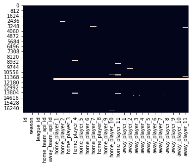

```python
sns.heatmap(df_match_player.isnull(), cbar=False)
```

```python
missing_player_teams = pd.read_sql("""
                                    SELECT
                                        l.name league_name,
                                        m.season,
                                        (SELECT t.team_long_name FROM Team t
                                        WHERE t.team_api_id = m.home_team_api_id) home_team,
                                        (SELECT t.team_long_name FROM Team t
                                        WHERE t.team_api_id = m.away_team_api_id) away_team
                                    FROM Match m INNER JOIN League l
                                    ON l.id = m.league_id
                                    WHERE home_player_1 IS NULL
                                    AND home_player_2 IS NULL
                                    AND home_player_3 IS NULL
                                    AND home_player_4 IS NULL
                                    AND home_player_5 IS NULL
                                    AND home_player_6 IS NULL
                                    AND home_player_7 IS NULL
                                    AND home_player_8 IS NULL
                                    AND home_player_9 IS NULL
                                    AND home_player_10 IS NULL
                                    AND home_player_11 IS NULL
                                    AND away_player_1 IS NULL
                                    AND away_player_2 IS NULL
                                    AND away_player_3 IS NULL
                                    AND away_player_4 IS NULL
                                    AND away_player_5 IS NULL
                                    AND away_player_6 IS NULL
                                    AND away_player_7 IS NULL
                                    AND away_player_8 IS NULL
                                    AND away_player_9 IS NULL
                                    AND away_player_10 IS NULL
                                    AND away_player_11 IS NULL
                                    AND league_id in ('1729', '4769', '7809', '10257', '13274', '21518');""", conn)
missing_player_teams
```

|  | league_name | season | home_team | away_team |
| --- | --- | --- | --- | --- |
| 0 | Netherlands Eredivisie | 2008/2009 | De Graafschap | NAC Breda |
| 1 | Netherlands Eredivisie | 2008/2009 | N.E.C. | PSV |
| 2 | Netherlands Eredivisie | 2008/2009 | AZ | FC Twente |
| 3 | Netherlands Eredivisie | 2008/2009 | Heracles Almelo | Vitesse |
| 4 | Netherlands Eredivisie | 2008/2009 | Willem II | Roda JC Kerkrade |
| ... | ... | ... | ... | ... |
| 200 | Netherlands Eredivisie | 2008/2009 | Vitesse | ADO Den Haag |
| 201 | Netherlands Eredivisie | 2008/2009 | Roda JC Kerkrade | Feyenoord |
| 202 | Netherlands Eredivisie | 2008/2009 | Sparta Rotterdam | N.E.C. |
| 203 | Netherlands Eredivisie | 2008/2009 | FC Volendam | De Graafschap |
| 204 | Netherlands Eredivisie | 2008/2009 | FC Utrecht | Heracles Almelo |

205 rows × 4 columns

```python
missing_player_teams.groupby('season')['league_name'].value_counts()
```

```
season     league_name
2008/2009  Netherlands Eredivisie    205
Name: league_name, dtype: int64
```

We observe that we lack data for all players from the Dutch league in the 2008/2009 season. Some information is also missing for other leagues. We will let it like that for the moment.

```python
df_team_player.info()
```

```
<class 'pandas.core.frame.DataFrame'>
Int64Index: 22545 entries, 0 to 42934
Data columns (total 3 columns):
 #   Column       Non-Null Count  Dtype
---  ------       --------------  -----
 0   season       22545 non-null  object
 1   team_api_id  22545 non-null  int64
 2   player       22545 non-null  float64
dtypes: float64(1), int64(1), object(1)
memory usage: 704.5+ KB
```

```python
df_team_player.duplicated().value_counts()
```

```
False    22545
dtype: int64
```

The team player dataframe is complete and without any duplicates.

```python
df_player.info()
```

```
<class 'pandas.core.frame.DataFrame'>
RangeIndex: 11060 entries, 0 to 11059
Data columns (total 7 columns):
 #   Column              Non-Null Count  Dtype
---  ------              --------------  -----
 0   id                  11060 non-null  int64
 1   player_api_id       11060 non-null  int64
 2   player_name         11060 non-null  object
 3   player_fifa_api_id  11060 non-null  int64
 4   birthday            11060 non-null  object
 5   height              11060 non-null  float64
 6   weight              11060 non-null  int64
dtypes: float64(1), int64(4), object(2)
memory usage: 605.0+ KB
```

```python
df_playeratt.head()
```

|  | id | player_fifa_api_id | player_api_id | date | overall_rating | potential | preferred_foot | attacking_work_rate | defensive_work_rate | crossing | ... | vision | penalties | marking | standing_tackle | sliding_tackle | gk_diving | gk_handling | gk_kicking | gk_positioning | gk_reflexes |
| --- | --- | --- | --- | --- | --- | --- | --- | --- | --- | --- | --- | --- | --- | --- | --- | --- | --- | --- | --- | --- | --- |
| 0 | 1 | 218353 | 505942 | 2016-02-18 00:00:00 | 67.0 | 71.0 | right | medium | medium | 49.0 | ... | 54.0 | 48.0 | 65.0 | 69.0 | 69.0 | 6.0 | 11.0 | 10.0 | 8.0 | 8.0 |
| 1 | 2 | 218353 | 505942 | 2015-11-19 00:00:00 | 67.0 | 71.0 | right | medium | medium | 49.0 | ... | 54.0 | 48.0 | 65.0 | 69.0 | 69.0 | 6.0 | 11.0 | 10.0 | 8.0 | 8.0 |
| 2 | 3 | 218353 | 505942 | 2015-09-21 00:00:00 | 62.0 | 66.0 | right | medium | medium | 49.0 | ... | 54.0 | 48.0 | 65.0 | 66.0 | 69.0 | 6.0 | 11.0 | 10.0 | 8.0 | 8.0 |
| 3 | 4 | 218353 | 505942 | 2015-03-20 00:00:00 | 61.0 | 65.0 | right | medium | medium | 48.0 | ... | 53.0 | 47.0 | 62.0 | 63.0 | 66.0 | 5.0 | 10.0 | 9.0 | 7.0 | 7.0 |
| 4 | 5 | 218353 | 505942 | 2007-02-22 00:00:00 | 61.0 | 65.0 | right | medium | medium | 48.0 | ... | 53.0 | 47.0 | 62.0 | 63.0 | 66.0 | 5.0 | 10.0 | 9.0 | 7.0 | 7.0 |

5 rows × 42 columns

```python
df_playeratt.info()
```

```
<class 'pandas.core.frame.DataFrame'>
RangeIndex: 183978 entries, 0 to 183977
Data columns (total 42 columns):
 #   Column               Non-Null Count   Dtype
---  ------               --------------   -----
 0   id                   183978 non-null  int64
 1   player_fifa_api_id   183978 non-null  int64
 2   player_api_id        183978 non-null  int64
 3   date                 183978 non-null  object
 4   overall_rating       183142 non-null  float64
 5   potential            183142 non-null  float64
 6   preferred_foot       183142 non-null  object
 7   attacking_work_rate  180748 non-null  object
 8   defensive_work_rate  183142 non-null  object
 9   crossing             183142 non-null  float64
```

[output cut: 34 more lines]

There are some missing values, but we will see if we really need all rows later on.

Eventually, before performing analysis on teams points in each league, we need to define two new columns in df_match that indicate how many points each team brings back. A win brings 3 points, a draw 1 point and a loss 0 point.

```python
df_match.loc[df_match['home_team_goal'] < df_match['away_team_goal'], 'home_team_points'] = 0
df_match.loc[df_match['home_team_goal'] == df_match['away_team_goal'], 'home_team_points'] = 1
df_match.loc[df_match['home_team_goal'] > df_match['away_team_goal'], 'home_team_points'] = 3

df_match.loc[df_match['home_team_goal'] < df_match['away_team_goal'], 'away_team_points'] = 3
df_match.loc[df_match['home_team_goal'] == df_match['away_team_goal'], 'away_team_points'] = 1
df_match.loc[df_match['home_team_goal'] > df_match['away_team_goal'], 'away_team_points'] = 0

df_match
```

|  | id | country_id | country | league_id | league | season | stage | match_api_id | home_team_api_id | away_team_api_id | home_team_goal | away_team_goal | home_team_points | away_team_points |
| --- | --- | --- | --- | --- | --- | --- | --- | --- | --- | --- | --- | --- | --- | --- |
| 0 | 1729 | 1729 | England | 1729 | England Premier League | 2008/2009 | 1 | 489042 | 10260 | 10261 | 1 | 1 | 1.0 | 1.0 |
| 1 | 1730 | 1729 | England | 1729 | England Premier League | 2008/2009 | 1 | 489043 | 9825 | 8659 | 1 | 0 | 3.0 | 0.0 |
| 2 | 1731 | 1729 | England | 1729 | England Premier League | 2008/2009 | 1 | 489044 | 8472 | 8650 | 0 | 1 | 0.0 | 3.0 |
| 3 | 1732 | 1729 | England | 1729 | England Premier League | 2008/2009 | 1 | 489045 | 8654 | 8528 | 2 | 1 | 3.0 | 0.0 |
| 4 | 1733 | 1729 | England | 1729 | England Premier League | 2008/2009 | 1 | 489046 | 10252 | 8456 | 4 | 2 | 3.0 | 0.0 |
| ... | ... | ... | ... | ... | ... | ... | ... | ... | ... | ... | ... | ... | ... | ... |
| 17028 | 24553 | 21518 | Spain | 21518 | Spain LIGA BBVA | 2015/2016 | 9 | 2030167 | 9906 | 10267 | 2 | 1 | 3.0 | 0.0 |
| 17029 | 24554 | 21518 | Spain | 21518 | Spain LIGA BBVA | 2015/2016 | 9 | 2030168 | 9864 | 9783 | 2 | 0 | 3.0 | 0.0 |
| 17030 | 24555 | 21518 | Spain | 21518 | Spain LIGA BBVA | 2015/2016 | 9 | 2030169 | 8315 | 9869 | 3 | 0 | 3.0 | 0.0 |
| 17031 | 24556 | 21518 | Spain | 21518 | Spain LIGA BBVA | 2015/2016 | 9 | 2030170 | 7878 | 8603 | 1 | 1 | 1.0 | 1.0 |
| 17032 | 24557 | 21518 | Spain | 21518 | Spain LIGA BBVA | 2015/2016 | 9 | 2030171 | 8370 | 8558 | 3 | 0 | 3.0 | 0.0 |

17033 rows × 14 columns

We want to get a match dataframe with tidy data (for now we have two columns for home and away teams, and two columns for home and away teams' goals).

```python
#Melting the team id columns
df_match_team = df_match.melt(id_vars=['id', 'country_id', 'country', 'league_id', 'league', 'season', 'stage', 'match_api_id'],
                              value_vars=['home_team_api_id', 'away_team_api_id'],
                              var_name='home_away',
                              value_name='team_api_id')
#Creating a column only containing 'home_team' or 'away_team'
df_match_team.loc[:,'home_away'] = df_match_team.loc[:,'home_away'].str.replace('_api_id', '')
```

```python
#Melting the team goals columns
df_match_goal = df_match.melt(id_vars=['id', 'country_id', 'country', 'league_id', 'league', 'season', 'stage', 'match_api_id'],
                              value_vars=['home_team_goal', 'away_team_goal'],
                              var_name='home_away',
                              value_name='team_goal')
#Creating a column only containing 'home_team' or 'away_team', which gives us the possibility to merge dataframes
df_match_goal.loc[:, 'home_away'] = df_match_goal.loc[:, 'home_away'].str.replace('_goal', '')
```

```python
#Melting the team points columns
df_match_points = df_match.melt(id_vars=['id', 'country_id', 'country', 'league_id', 'league', 'season', 'stage', 'match_api_id'],
                              value_vars=['home_team_points', 'away_team_points'],
                              var_name='home_away',
                              value_name='team_points')
#Creating a column only containing 'home_team' or 'away_team', which gives us the possibility to merge dataframes
df_match_points.loc[:, 'home_away'] = df_match_goal.loc[:, 'home_away'].str.replace('_points', '')
```

```python
#Creating another dataframe to store the goals conceded by a team and melting it
df_goals_conceded = df_match.copy()
df_goals_conceded['home_team_goal_conceded'] = df_match['away_team_goal']
df_goals_conceded['away_team_goal_conceded'] = df_match['home_team_goal']
df_goals_conceded = df_goals_conceded.melt(id_vars=['id', 'country_id', 'country', 'league_id', 'league', 'season', 'stage', 'match_api_id'],
                              value_vars=['home_team_goal_conceded', 'away_team_goal_conceded'],
                              var_name='home_away',
                              value_name='goal_conceded')
#Creating a column only containing 'home_team' or 'away_team', which gives us the possibility to merge dataframes
df_goals_conceded.loc[:, 'home_away'] = df_goals_conceded.loc[:, 'home_away'].str.replace('_goal_conceded', '')
```

```python
#Merging the dataframes back to get a final tidy dataframe that replaces the initial df_match dataframe
df_match = df_match_team.merge(right=df_match_goal, how='inner',
                               on=['id', 'country_id', 'country', 'league_id', 'league', 'season', 'stage', 'match_api_id', 'home_away'])
df_match = df_match.merge(right=df_match_points, how='inner',
                         on=['id', 'country_id', 'country', 'league_id', 'league', 'season', 'stage', 'match_api_id', 'home_away'])
df_match = df_match.merge(right=df_goals_conceded, how='inner',
                         on=['id', 'country_id', 'country', 'league_id', 'league', 'season', 'stage', 'match_api_id', 'home_away'])
df_match
```

|  | id | country_id | country | league_id | league | season | stage | match_api_id | home_away | team_api_id | team_goal | team_points | goal_conceded |
| --- | --- | --- | --- | --- | --- | --- | --- | --- | --- | --- | --- | --- | --- |
| 0 | 1729 | 1729 | England | 1729 | England Premier League | 2008/2009 | 1 | 489042 | home_team | 10260 | 1 | 1.0 | 1 |
| 1 | 1730 | 1729 | England | 1729 | England Premier League | 2008/2009 | 1 | 489043 | home_team | 9825 | 1 | 3.0 | 0 |
| 2 | 1731 | 1729 | England | 1729 | England Premier League | 2008/2009 | 1 | 489044 | home_team | 8472 | 0 | 0.0 | 1 |
| 3 | 1732 | 1729 | England | 1729 | England Premier League | 2008/2009 | 1 | 489045 | home_team | 8654 | 2 | 3.0 | 1 |
| 4 | 1733 | 1729 | England | 1729 | England Premier League | 2008/2009 | 1 | 489046 | home_team | 10252 | 4 | 3.0 | 2 |
| ... | ... | ... | ... | ... | ... | ... | ... | ... | ... | ... | ... | ... | ... |
| 34061 | 24553 | 21518 | Spain | 21518 | Spain LIGA BBVA | 2015/2016 | 9 | 2030167 | away_team | 10267 | 1 | 0.0 | 2 |
| 34062 | 24554 | 21518 | Spain | 21518 | Spain LIGA BBVA | 2015/2016 | 9 | 2030168 | away_team | 9783 | 0 | 0.0 | 2 |
| 34063 | 24555 | 21518 | Spain | 21518 | Spain LIGA BBVA | 2015/2016 | 9 | 2030169 | away_team | 9869 | 0 | 0.0 | 3 |
| 34064 | 24556 | 21518 | Spain | 21518 | Spain LIGA BBVA | 2015/2016 | 9 | 2030170 | away_team | 8603 | 1 | 1.0 | 1 |
| 34065 | 24557 | 21518 | Spain | 21518 | Spain LIGA BBVA | 2015/2016 | 9 | 2030171 | away_team | 8558 | 0 | 0.0 | 3 |

34066 rows × 13 columns

We finally have a tidy dataframe with season, league, match, team (home and away), goals scored (and conceded) and points!

## Exploratory data analysis

Questions

- Is there really an advantage in playing at home? At least, is playing at home associated with more chances of winning?
- Which teams are the best performers over the years?
- How are the teams attributes correlated with teams performances?

### Home advantage

```python
home_advantage = df_match.groupby(by=['league', 'home_away'], as_index=False)['team_goal'].mean()
home_advantage
```

|  | league | home_away | team_goal |
| --- | --- | --- | --- |
| 0 | England Premier League | away_team | 1.159539 |
| 1 | England Premier League | home_team | 1.550987 |
| 2 | France Ligue 1 | away_team | 1.040132 |
| 3 | France Ligue 1 | home_team | 1.402961 |
| 4 | Germany 1. Bundesliga | away_team | 1.274918 |
| 5 | Germany 1. Bundesliga | home_team | 1.626634 |
| 6 | Italy Serie A | away_team | 1.116009 |
| 7 | Italy Serie A | home_team | 1.500829 |
| 8 | Netherlands Eredivisie | away_team | 1.301062 |
| 9 | Netherlands Eredivisie | home_team | 1.779820 |
| 10 | Spain LIGA BBVA | away_team | 1.135855 |
| 11 | Spain LIGA BBVA | home_team | 1.631250 |

```python
fig = px.bar(home_advantage, x='league', y='team_goal',
             color='home_away', barmode='group')
fig.update_layout(title='Average goals scored per match for home and away teams',
                  yaxis_title='Average goals scored per match',
                  xaxis_title='League',
                  legend_title='')
#add annotations with the difference between average home goals and away goals
for league in df_league['name'].tolist():
    mean_goal = ((home_advantage[(home_advantage['league']==league) & (home_advantage['home_away']=='home_team')]['team_goal'].values
                 + home_advantage[(home_advantage['league']==league) & (home_advantage['home_away']=='away_team')]['team_goal'].values)/2).item()

    goal_difference = (home_advantage[(home_advantage['league']==league) & (home_advantage['home_away']=='home_team')]['team_goal'].values
                       - home_advantage[(home_advantage['league']==league) & (home_advantage['home_away']=='away_team')]['team_goal'].values).item()

    fig.add_annotation(
        x=league,
        y=round(mean_goal,2),
        text=round(goal_difference,2),
        showarrow=False,
        font=dict(color='dimgrey', size=20))
# print(fig.layout)
fig.show()
```

[interactive chart not shown]

We can see that, on average, home teams score approximately 0.4 more goals (between 0.35 and 0.5) than their away counterpart. It seems that this difference is more pronounced in the Spanish and Dutch leagues.

### Best performing teams

For this analysis, we will retrieve teams name from df_team. Eventually, we want to see if any correlation exists between team attributes and team performance. We can consider team performance with different proxies: total goals scored, total points per season and goals scored per match.

```python
#Grouping by country, league, season and team_api_id and summing up points
performers = df_match.groupby(['country', 'league', 'season', 'team_api_id'])['team_goal', 'team_points'].agg(['sum', 'count']).reset_index()
#Dropping last column (count duplicate, corresponding to the number of matches played)
performers = performers.iloc[:, :-1]
#Renaming columns
performers.columns=['country', 'league', 'season', 'team_api_id', 'team_goal', 'matches', 'team_points']
#Creating a column with goals per match
performers.loc[:, 'goal_per_match'] = performers['team_goal']/performers['matches']

#Merging with df_team to get teams name
performers = performers.merge(right=df_team, left_on='team_api_id', right_on='team_api_id')
performers = performers[['country', 'league', 'season', 'team_api_id', 'team_long_name', 'team_goal', 'team_points', 'goal_per_match']].rename(columns={'team_long_name':'team'})

#Creating a column with team name and season
performers.loc[:, 'team_season'] = performers['team']+ ' ' + performers['season'].astype('str')
```

#### Teams that scored the most goals

```python
top_scoring_teams = performers.sort_values('team_goal', ascending=False)[:20]
fig = px.bar(top_scoring_teams, x='team_season', y='team_goal', color='team')
fig.update_layout(images = [
                            {"source": "images/real_madrid.png",
                             "xref": "x",
                             "yref": "y",
                             "x": 4,
                             "y": 50,
                             "sizex": 30,
                             "sizey": 30,
                             "xanchor": "right",
                             "yanchor": "bottom"},
                            {"source": "images/fc_barcelona.png",
                             "xref": "x",
                             "yref": "y",
                             "x": 10.5,
                             "y": 50,
                             "sizex": 24,
                             "sizey": 24,
                             "xanchor": "right",
                             "yanchor": "bottom"},
                            {"source": "images/ajax.png",
                             "xref": "x",
                             "yref": "y",
                             "x": 13.5,
                             "y": 110,
                             "sizex": 15,
                             "sizey": 15,
                             "xanchor": "right",
                             "yanchor": "bottom"},
                            {"source": "images/psv.png",
                             "xref": "x",
                             "yref": "y",
                             "x": 14.5,
                             "y": 112,
                             "sizex": 10,
                             "sizey": 10,
                             "xanchor": "right",
                             "yanchor": "bottom"},
                            {"source": "images/chelsea.png",
                             "xref": "x",
                             "yref": "y",
                             "x": 15.5,
                             "y": 110,
                             "sizex": 14,
                             "sizey": 14,
                             "xanchor": "right",
                             "yanchor": "bottom"},
                            {"source": "images/psg.png",
                             "xref": "x",
                             "yref": "y",
                             "x": 16.5,
                             "y": 110,
                             "sizex": 14,
                             "sizey": 14,
                             "xanchor": "right",
                             "yanchor": "bottom"},
                            {"source": "images/man_city.png",
                             "xref": "x",
                             "yref": "y",
                             "x": 17.5,
                             "y": 110,
                             "sizex": 14,
                             "sizey": 14,
                             "xanchor": "right",
                             "yanchor": "bottom"},
                            {"source": "images/liverpool.png",
                             "xref": "x",
                             "yref": "y",
                             "x": 18.37,
                             "y": 110,
                             "sizex": 14,
                             "sizey": 14,
                             "xanchor": "right",
                             "yanchor": "bottom"},
                            {"source": "images/bayern.png",
                             "xref": "x",
                             "yref": "y",
                             "x": 19.4,
                             "y": 110,
                             "sizex": 14,
                             "sizey": 14,
                             "xanchor": "right",
                             "yanchor": "bottom"}
                            ],
                 title = 'Top scoring teams',
                 yaxis_title = 'Total goals',
                 xaxis_title = 'Team')
fig.show()
```

[interactive chart not shown]

This chart illustrates the domination imposed by the two Spanish leaders in terms of goals scored per season.

#### Teams with the best defense

To compare teams in terms of defense, we will use the total number of goals conceded as a proxy.

```python
best_defenses = df_match.groupby(['country', 'league', 'season', 'team_api_id'])['goal_conceded'].sum().reset_index()

#Merging with df_team to get teams name
best_defenses = best_defenses.merge(right=df_team, left_on='team_api_id', right_on='team_api_id')
best_defenses = best_defenses[['country', 'league', 'season', 'team_api_id', 'team_long_name', 'goal_conceded']].rename(columns={'team_long_name':'team'})

#Creating a column with team name and season
best_defenses.loc[:, 'team_season'] = best_defenses['team']+ ' ' + best_defenses['season'].astype('str')
```

```python
top_defenses = best_defenses.sort_values('goal_conceded', ascending=True)[:10]
fig = px.bar(top_defenses, x='team_season', y='goal_conceded', color='team')
fig.update_layout(title = 'Top 10 teams - least goals conceded',
                 yaxis_title = 'Total goals conceded',
                 xaxis_title = 'Team',
                 images = [
                            {"source": "images/bayern.png",
                             "xref": "x",
                             "yref": "y",
                             "x": 1.5,
                             "y": 8,
                             "sizex": 5,
                             "sizey": 5,
                             "xanchor": "right",
                             "yanchor": "bottom"},
                             {"source": "images/atletico.png",
                             "xref": "x",
                             "yref": "y",
                             "x": 3.37,
                             "y": 8,
                             "sizex": 5,
                             "sizey": 5,
                             "xanchor": "right",
                             "yanchor": "bottom"},
                             {"source": "images/psg.png",
                             "xref": "x",
                             "yref": "y",
                             "x": 4.5,
                             "y": 8,
                             "sizex": 5,
                             "sizey": 5,
                             "xanchor": "right",
                             "yanchor": "bottom"},
                             {"source": "images/juventus.png",
                             "xref": "x",
                             "yref": "y",
                             "x": 5.7,
                             "y": 8,
                             "sizex": 5,
                             "sizey": 5,
                             "xanchor": "right",
                             "yanchor": "bottom"},
                             {"source": "images/ajax.png",
                             "xref": "x",
                             "yref": "y",
                             "x": 7.5,
                             "y": 8,
                             "sizex": 5,
                             "sizey": 5,
                             "xanchor": "right",
                             "yanchor": "bottom"},
                             {"source": "images/fc_barcelona.png",
                             "xref": "x",
                             "yref": "y",
                             "x": 9,
                             "y": 8,
                             "sizex": 5,
                             "sizey": 5,
                             "xanchor": "right",
                             "yanchor": "bottom"}]
                 )
fig.show()
```

[interactive chart not shown]

Looking at best performing teams by season.

```python
df_teamatt.head()
```

|  | id | team_fifa_api_id | team_api_id | date | buildUpPlaySpeed | buildUpPlaySpeedClass | buildUpPlayDribbling | buildUpPlayDribblingClass | buildUpPlayPassing | buildUpPlayPassingClass | ... | chanceCreationShooting | chanceCreationShootingClass | chanceCreationPositioningClass | defencePressure | defencePressureClass | defenceAggression | defenceAggressionClass | defenceTeamWidth | defenceTeamWidthClass | defenceDefenderLineClass |
| --- | --- | --- | --- | --- | --- | --- | --- | --- | --- | --- | --- | --- | --- | --- | --- | --- | --- | --- | --- | --- | --- |
| 0 | 1 | 434 | 9930 | 2010-02-22 00:00:00 | 60 | Balanced | 30.485714 | Little | 50 | Mixed | ... | 55 | Normal | Organised | 50 | Medium | 55 | Press | 45 | Normal | Cover |
| 1 | 2 | 434 | 9930 | 2014-09-19 00:00:00 | 52 | Balanced | 48.000000 | Normal | 56 | Mixed | ... | 64 | Normal | Organised | 47 | Medium | 44 | Press | 54 | Normal | Cover |
| 2 | 3 | 434 | 9930 | 2015-09-10 00:00:00 | 47 | Balanced | 41.000000 | Normal | 54 | Mixed | ... | 64 | Normal | Organised | 47 | Medium | 44 | Press | 54 | Normal | Cover |
| 3 | 4 | 77 | 8485 | 2010-02-22 00:00:00 | 70 | Fast | 30.485714 | Little | 70 | Long | ... | 70 | Lots | Organised | 60 | Medium | 70 | Double | 70 | Wide | Cover |
| 4 | 5 | 77 | 8485 | 2011-02-22 00:00:00 | 47 | Balanced | 30.485714 | Little | 52 | Mixed | ... | 52 | Normal | Organised | 47 | Medium | 47 | Press | 52 | Normal | Cover |

5 rows × 25 columns

```python
#We will change the dates a bit to coincide with the season
season_dict = {'2010-02-22 00:00:00' : '2010/2011',
               '2011-02-22 00:00:00' : '2011/2012',
               '2012-02-22 00:00:00' : '2012/2013',
               '2013-09-20 00:00:00' : '2013/2014',
               '2014-09-19 00:00:00' : '2014/2015',
               '2015-09-10 00:00:00' : '2015/2016'}
#Replacing df_teamatt 'date' column values with season_dict
df_teamatt.loc[:, 'date'] = df_teamatt.loc[:, 'date'].map(season_dict)
df_teamatt.rename(columns={'date':'season'}, inplace=True)

#Keeping only seasons between 2010/2011 and 2015/2016
performers = performers[performers['season'].isin(['2010/2011', '2011/2012', '2012/2013', '2013/2014', '2014/2015', '2015/2016'])]

#Merging performers with df_teamatt
performers = performers.merge(right=df_teamatt, on=['season', 'team_api_id'])

#Dropping 'id' and 'team_fifa_api_id' columns
performers.drop(columns=['id', 'team_fifa_api_id'], inplace=True)

#Dropping attributes columns with categorical variables (all columns with 'Class')
performers.drop(columns=[x for x in performers.columns if 'Class' in x], inplace=True)
```

```python
performers.head()
```

|  | country | league | season | team_api_id | team | team_goal | team_points | goal_per_match | team_season | buildUpPlaySpeed | buildUpPlayDribbling | buildUpPlayPassing | chanceCreationPassing | chanceCreationCrossing | chanceCreationShooting | defencePressure | defenceAggression | defenceTeamWidth |
| --- | --- | --- | --- | --- | --- | --- | --- | --- | --- | --- | --- | --- | --- | --- | --- | --- | --- | --- |
| 0 | England | England Premier League | 2010/2011 | 8455 | Chelsea | 69 | 71.0 | 1.815789 | Chelsea 2010/2011 | 70 | 30.485714 | 60 | 56 | 70 | 70 | 30 | 60 | 35 |
| 1 | England | England Premier League | 2011/2012 | 8455 | Chelsea | 65 | 64.0 | 1.710526 | Chelsea 2011/2012 | 60 | 30.485714 | 50 | 60 | 60 | 80 | 35 | 55 | 50 |
| 2 | England | England Premier League | 2012/2013 | 8455 | Chelsea | 75 | 75.0 | 1.973684 | Chelsea 2012/2013 | 60 | 30.485714 | 45 | 55 | 45 | 45 | 60 | 62 | 46 |
| 3 | England | England Premier League | 2013/2014 | 8455 | Chelsea | 71 | 82.0 | 1.868421 | Chelsea 2013/2014 | 46 | 30.485714 | 41 | 46 | 61 | 63 | 42 | 43 | 46 |
| 4 | England | England Premier League | 2014/2015 | 8455 | Chelsea | 73 | 87.0 | 1.921053 | Chelsea 2014/2015 | 67 | 52.000000 | 38 | 41 | 61 | 68 | 39 | 41 | 46 |

#### Comparing average attributes

Let's see if we can find any link between a variable containing an average of all attributes and the 3 teams performances indicators (total goals per season, team points, goals per match).

```python
#Building a new variable avg_att
performers.loc[:, 'avg_att'] = performers.iloc[:, 8:].mean(axis=1)
performers.info()
```

```
<class 'pandas.core.frame.DataFrame'>
Int64Index: 683 entries, 0 to 682
Data columns (total 19 columns):
 #   Column                  Non-Null Count  Dtype
---  ------                  --------------  -----
 0   country                 683 non-null    object
 1   league                  683 non-null    object
 2   season                  683 non-null    object
 3   team_api_id             683 non-null    int64
 4   team                    683 non-null    object
 5   team_goal               683 non-null    int64
 6   team_points             683 non-null    float64
 7   goal_per_match          683 non-null    float64
 8   team_season             683 non-null    object
 9   buildUpPlaySpeed        683 non-null    int64
 10  buildUpPlayDribbling    683 non-null    float64
 11  buildUpPlayPassing      683 non-null    int64
 12  chanceCreationPassing   683 non-null    int64
 13  chanceCreationCrossing  683 non-null    int64
 14  chanceCreationShooting  683 non-null    int64
 15  defencePressure         683 non-null    int64
 16  defenceAggression       683 non-null    int64
 17  defenceTeamWidth        683 non-null    int64
 18  avg_att                 683 non-null    float64
dtypes: float64(4), int64(10), object(5)
memory usage: 106.7+ KB
```

```python
fig = px.scatter(performers, x='avg_att', y='team_goal')
fig.show()
```

[interactive chart not shown]

```python
fig = px.scatter(performers, x='avg_att', y='team_points')
fig.show()
```

[interactive chart not shown]

```python
fig = px.scatter(performers, x='avg_att', y='goal_per_match')
fig.show()
```

[interactive chart not shown]

```python
performers.loc[:, ['team_goal', 'team_points', 'goal_per_match', 'avg_att']].corr()
```

|  | team_goal | team_points | goal_per_match | avg_att |
| --- | --- | --- | --- | --- |
| team_goal | 1.000000 | 0.861334 | 0.985253 | -0.008235 |
| team_points | 0.861334 | 1.000000 | 0.820584 | 0.035206 |
| goal_per_match | 0.985253 | 0.820584 | 1.000000 | -0.027214 |
| avg_att | -0.008235 | 0.035206 | -0.027214 | 1.000000 |

At this point, we cannot see any clear pattern between team average attributes and their performance considering the three proxies selected. We will pursue the analysis with other techniques.